# Big Data Analysis in Finance

Module 2

Author

Affiliation

Prof. Matthew G. Son

University of South Florida

# Data merge/join

## Data joining: keys

It is unlikely that data involves only a single data frame

- You must **join** tables together

When you want to join two tables, you must find **keys**:

1. **Primary key**: set of variable(s) that **uniquely** identifies each observation.
2. **Foreign key**: set of variable(s) that corresponds to primary key in another table.

## Example: Financials and Stock prices

Stock price data: contains daily stock prices

- key: `symbol` and `date`

```r
library(tidyquant)
symbols <- c("AAPL","MSFT", "TSLA", "GME")
stock_prices <- tq_get(symbols, from = "2023-01-01", to = "2023-12-31")
stock_prices |> slice_head(n = 1, by = symbol)
```

```
# A tibble: 4 × 8
  symbol date        open  high   low close    volume adjusted
  <chr>  <date>     <dbl> <dbl> <dbl> <dbl>     <dbl>    <dbl>
1 AAPL   2023-01-03 130.  131.  124.  125.  112117500    124.
2 MSFT   2023-01-03 243.  246.  237.  240.   25740000    235.
3 TSLA   2023-01-03 118.  119.  105.  108.  231402800    108.
4 GME    2023-01-03  18.6  19.3  17.1  17.2   5135200     17.2
```

Index data: contains index constituents

- key: `symbol`

```r
sp500_index <- tq_index("SP500")
```

```
Getting holdings for SP500
```

```r
sp500_index |> head(4)
```

```
# A tibble: 4 × 8
  symbol company       identifier sedol weight sector shares_held local_currency
  <chr>  <chr>         <chr>      <chr>  <dbl> <chr>        <dbl> <chr>
1 AAPL   APPLE INC     037833100  2046… 0.0681 -        183025769 USD
2 MSFT   MICROSOFT CO… 594918104  2588… 0.0604 -         90574052 USD
3 NVDA   NVIDIA CORP   67066G104  2379… 0.0599 -        298381059 USD
4 AMZN   AMAZON.COM I… 023135106  2000… 0.0384 -        114917259 USD
```

## Checking primary keys

How can we identify primary keys?

- Browse the dictionary, data and see which variable overlaps
- Make sure the key(s) **uniquely** identify each observations (rows) for the table

$$\text{# of distinct values of key} == \text{N}$$

The number of distinct values of the key should equal to **total number of rows**.

## Guide on primary key checking

*Step 1. Check if missing values*

If key variable(s) contain missing values, it might be from data corruption.

If it contains missing values, consider dropping missing rows, or search other potential keys.

```r
# symbol and date are key variables
stock_prices |>
  filter(if_any(c(symbol, date), is.na)) |>
  nrow()
```

```
[1] 0
```

*Step 2. Check if uniquely identify*

```r
# Check number of distinct values equals num obervations
stock_prices |>
  summarize(n_distinct(symbol,date) == n())
```

```
# A tibble: 1 × 1
  `n_distinct(symbol, date) == n()`
  <lgl>
1 TRUE
```

## Exercise

Load `tidyverse` and `tidyquant`.

1. Download stock prices and name it as `stock_prices`
- Tickers: `F` and `GME`
- Dates: Whole year 2023
2. Download S&P 500 index holdings as `sp500_holdings`
- Use `tq_index("SP500")`
3. How many observations (nrows) are found in `sp500_holdings`?
4. Check if there are any missing values in key variable in the `sp500_holdings`
5. Does the key variable uniquely identify all observations?

## Basic joins (Equi-joins)

Basic joins are when both primary and foreign keys **exactly match**.

1. Mutating joins:
   - Primary purpose is to **add more columns**
   - `left_join()`, `right_join()`, `inner_join()`, `full_join()`
2. Filtering joins:
   - Primary purpose is to **filter rows**
   - `semi_join()`, `anti_join()`

## Join diagrams

We have to determine what happens when keys are **NOT MATCHED**

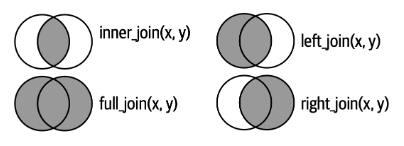

## Left Join

When non-matching, NA fill (left alive) or drop (right die).

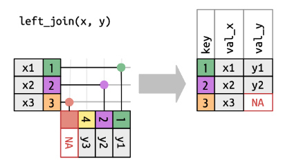

## Right Join

When non-matching, drop (left die), NA fill (right alive).

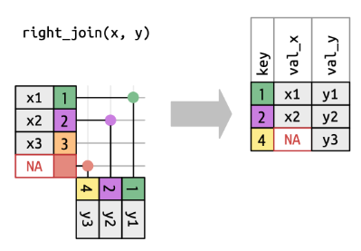

## Mutating joins (Left Join)

```r
left_data |>
  left_join(
    right_data,
    by = join_by(left_key == right_key)
  )
```

- The information from the left data.frame is **not lost**
- Most intuitive and popular join

Left join `sp500_index` to `stock_prices`

```r
stock_prices_on_left <- stock_prices |> # stock_prices on the left
  left_join(sp500_index, by = join_by(symbol))
stock_prices_on_left |> head(3)
```

```
# A tibble: 3 × 15
  symbol date        open  high   low close   volume adjusted company identifier
  <chr>  <date>     <dbl> <dbl> <dbl> <dbl>    <dbl>    <dbl> <chr>   <chr>
1 AAPL   2023-01-03  130.  131.  124.  125.   1.12e8     124. APPLE … 037833100
2 AAPL   2023-01-04  127.  129.  125.  126.   8.91e7     125. APPLE … 037833100
3 AAPL   2023-01-05  127.  128.  125.  125.   8.10e7     124. APPLE … 037833100
# ℹ 5 more variables: sedol <chr>, weight <dbl>, sector <chr>,
#   shares_held <dbl>, local_currency <chr>
```

Conversely, left join `stock_prices` to `sp500_index`

```r
sp500_index_on_left <- sp500_index |> # sp500_index on the left
  left_join(stock_prices, by = join_by(symbol))
sp500_index_on_left |> head(3)
```

```
# A tibble: 3 × 15
  symbol company   identifier sedol   weight sector shares_held local_currency
  <chr>  <chr>     <chr>      <chr>    <dbl> <chr>        <dbl> <chr>
1 AAPL   APPLE INC 037833100  2046251 0.0681 -        183025769 USD
2 AAPL   APPLE INC 037833100  2046251 0.0681 -        183025769 USD
3 AAPL   APPLE INC 037833100  2046251 0.0681 -        183025769 USD
# ℹ 7 more variables: date <date>, open <dbl>, high <dbl>, low <dbl>,
#   close <dbl>, volume <dbl>, adjusted <dbl>
```

Which data is considered left makes difference!

```r
dim(stock_prices_on_left)
```

```
[1] 1000   15
```

```r
dim(sp500_index_on_left)
```

```
[1] 1251   15
```

## Exercise (Homework)

Refer to below sample code & syntax:

Load `tidyverse` and `tidyquant`.

1. Download stock prices and name it as `stock_prices`
- Tickers: `F` and `GME`
- Dates: Whole year 2023
2. Download S&P 500 index holdings as `sp500_holdings`
- Use `tq_index("SP500")`

## Exercise (continued)

3. Left join `sp500_holdings` to `stock_prices`. How many rows does it have?
4. Left join `stock_prices` to `sp500_holdings`. How many rows?
5. Right join `sp500_holdings` to `stock_prices`. How many rows does it have?
6. Right join `stock_prices` to `sp500_holdings`. How many rows?
7. Inner join `sp500_holdings` to `stock_prices`. How many rows does it have?

7a. Inner join `stock_prices` to `sp500_holdings`. What’s the difference?

8. Outer join `sp500_holdings` to `stock_prices`. How many rows does it have?

8a. Outer join `stock_prices` to `sp500_holdings`. How many rows?

## Filtering joins:

When you want to filter rows as the result of join. **No new columns generated**.

`semi_join()`: Keep all rows in left frame that have match in right frame

```r
stock_prices |>
  semi_join(sp500_index, by = join_by(symbol)) |>
  slice_head(n = 2, by = symbol)
```

```
# A tibble: 6 × 8
  symbol date        open  high   low close    volume adjusted
  <chr>  <date>     <dbl> <dbl> <dbl> <dbl>     <dbl>    <dbl>
1 AAPL   2023-01-03  130.  131.  124.  125. 112117500     124.
2 AAPL   2023-01-04  127.  129.  125.  126.  89113600     125.
3 MSFT   2023-01-03  243.  246.  237.  240.  25740000     235.
4 MSFT   2023-01-04  232.  233.  226.  229.  50623400     225.
5 TSLA   2023-01-03  118.  119.  105.  108. 231402800     108.
6 TSLA   2023-01-04  109.  115.  108.  114. 180389000     114.
```

`anti_join()`: Keep all rows that that is not found in the right frame.

```r
stock_prices |>
  anti_join(sp500_index, by = join_by(symbol)) |>
  slice_head(n = 2, by = symbol)
```

```
# A tibble: 2 × 8
  symbol date        open  high   low close  volume adjusted
  <chr>  <date>     <dbl> <dbl> <dbl> <dbl>   <dbl>    <dbl>
1 GME    2023-01-03  18.6  19.3  17.1  17.2 5135200     17.2
2 GME    2023-01-04  17.2  17.9  16.9  17.3 3939300     17.3
```

## Exercise

Type the code below and see what’s happening:

```r
stock_prices |>
  semi_join(sp500_index, by = join_by(symbol)) |>
  slice_head(n = 2, by = symbol)

stock_prices |>
  anti_join(sp500_index, by = join_by(symbol)) |>
  slice_head(n = 2, by = symbol)
```

## Advanced joins 1

**1:M (One to Many) matching**

*When foreign key is NOT uniquely identifying* each observations:

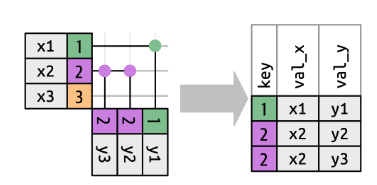

Inner join with duplicate key

A copy of row is generated (i.e. broadcasted) to guarantee matching.

**Important**

What would happen if you perform left / right / inner / outer (full) join when you have 1:M relationship?

Think about in terms of number of rows you will eventually have.

## Advanced joins 2

**Non-equi** joins:

when join includes inequality (e.g. `key1 >= key2`)

- Cross joins : match every pair, Cartesian product (M:M matching)
- Inequality joins: uses `<`, `>`, `>=`, `<=` instead of `==`
- **Rolling joins**: inequality with only closest matching (time series)
- **Overlap joins**: join when within a range

## Non-equi join example

**Rolling joins**

> Suppose you have data in two different time frequency.

> Stock trading data in minute-level frequency, and risk-free rate in daily (end-of-day) frequency.

> How can you match the most recent risk-free rate to each stock trading data?

## Non-equi join example 2

**Overlap joins**

> Suppose a specific company was merged and its ticker symbol changed from “AABB” to “AAC”, then to “ABC”.

> Some other company started to use “AABB” as its ticker.

> In this case, when joining, you want to match **ticker** AND with specific date that is between dates when ticker symbol was active for the specific company.

# SQL

## SQL

**Structured Query Language**

SQL is a query language for storing and processing information in relational database.

It is standardized and widely used database language.

## SQL basic verbs

Like `dplyr`, SQL has its own (but archaic) syntax:

- SELECT: choose variables for the table
- GROUP BY: group rows of data by grouper variable
- ORDER BY: arrange the rows by the variable
- WHERE: filter rows with given condition
- HAVING: Similar to where but used with group by to filter data
- JOIN: join tables, defaults INNER
- LIMIT: show the head of table
- WITH: temporary table for subquery

## SQL and dplyr

**SELECT, WHERE**

`WHERE` is filtering function:

```sql
SELECT symbol, date, adjusted
FROM stock_prices
WHERE symbol = 'AAPL';
```

Is equivalent to

```r
stock_prices |>
  filter(symbol == "AAPL") |>
  select(symbol, date, adjusted)
```

**GROUP BY + Mutate**

```sql
SELECT symbol, AVG(adjusted) AS avg_price, COUNT(*) AS num_days
FROM stock_prices
GROUP BY symbol;
```

is equivalent to

```r
stock_prices |>
  group_by(symbol) |>
  summarize(avg_price = mean(adjusted), num_days = n())
```

**HAVING**

`HAVING` is a another filtering that is evaluated **after** the `GROUP BY` operation.

```sql
SELECT
  symbol,
  AVG(adjusted) AS avg_price,
  SUM(volume) AS total_volume
FROM stock_prices
WHERE adjusted > 10
GROUP BY symbol
HAVING AVG(adjusted) > 50;
```

```r
stock_prices |>
  filter(adjusted > 10) |>
  group_by(symbol) |>
  summarize(
    avg_price = mean(adjusted),
    total_volume = sum(volume)
  ) |>
  filter(avg_price > 50)
```

**JOIN**

`JOIN` is `INNER JOIN` by default. Use `LEFT JOIN` for left join, etc.

```sql
SELECT sp.symbol, sp.date, sp.adjusted, si.sector
FROM stock_prices sp -- alias sp
JOIN sp500_index si ON sp.symbol = si.symbol;
```

Equivalent to

```r
stock_prices |>
  inner_join(sp500_index, by = join_by(symbol)) |>
  select(symbol, date, adjusted, sector)
```

**Complex Query**

Subqueries in SQL are written with “WITH”

```sql
WITH high_weight_symbols AS (
  SELECT symbol
  FROM sp500_index
  WHERE weight > 0.03
)
SELECT
  symbol,
  AVG(adjusted) AS avg_price,
  SUM(volume) AS total_volume
FROM stock_prices
WHERE symbol IN (SELECT symbol FROM high_weight_symbols)
GROUP BY symbol
HAVING AVG(adjusted) > 50;
```

In dplyr, store as interm object:

```r
high_weight_symbols <- sp500_index |>
  filter(weight > 0.03) |>
  pull(symbol)

stock_prices |>
  filter(symbol %in% high_weight_symbols) |>
  group_by(symbol) |>
  summarize(
    avg_price = mean(adjusted),
    total_volume = sum(volume)
  ) |>
  filter(avg_price > 50)
```

## Notes on SQL

SQL is (somehow) easier to read, but **it does NOT guarantee that the execution is in the order of writing**.

- The query usually starts with `SELECT`, but it is executed later.
- Confusingly, you have to write things in pre-defined order (`SELECT` then `FROM` then `WHERE` etc…)
- Also confusingly, some verbs have different nuances but does similar job (and vice versa)
  - `WHERE` and `HAVING`
  - `GROUP BY` and `PARTITION BY`
  - etc.

## Notes on SQL

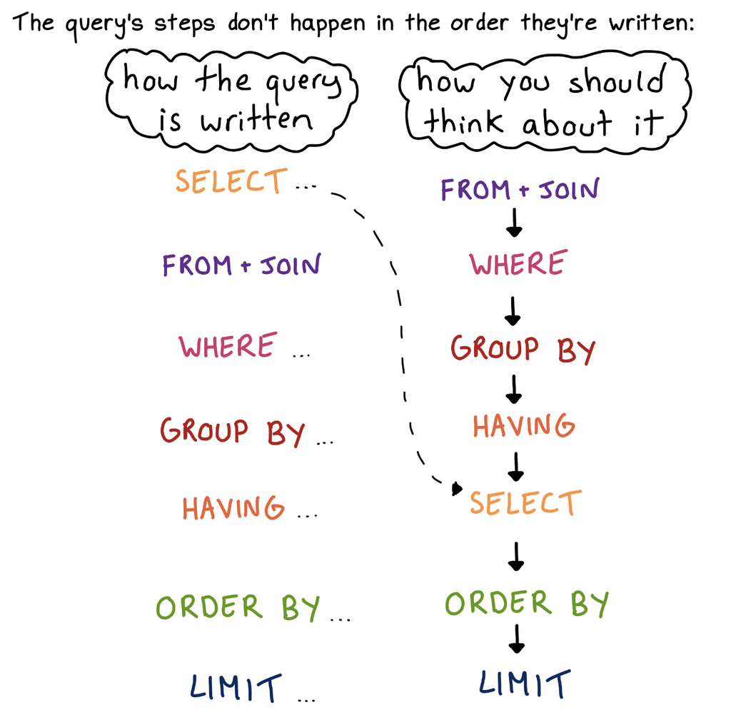

Source: Julia Evans, “Become a Select STAR”

# Database in R

## Prep

Connections pane in IDEs is helpful to understand and browse database. To enable, first install:

```r
install.packages("duckdb") # Our in-memory DB engine
install.packages("remotes") # Need remotes package for github pacakge installation
remotes::install_github("rstudio/connections") # Install package from github
```

## Open and Close connections

You can make a databse connection to anywhere:

- Local memory
- Local disk
- Remote databse

```r
library(connections)
# by default, it is in-memory connection
con <- connection_open(db_engine_name)
```

When finished, close connection with:

```r
connection_close(con)
```

## dbplyr: dplyr to SQL Databases

**Tip**

You can still use dplyr syntax to perform query on SQL databases, by using dplyr verbs on `dbplyr` object.

Package `dbplyr` converts dplyr to `SQL` code.

- `dbplyr` is called **backend** of `dplyr`

## Database Simulation

### Creating in-memory database

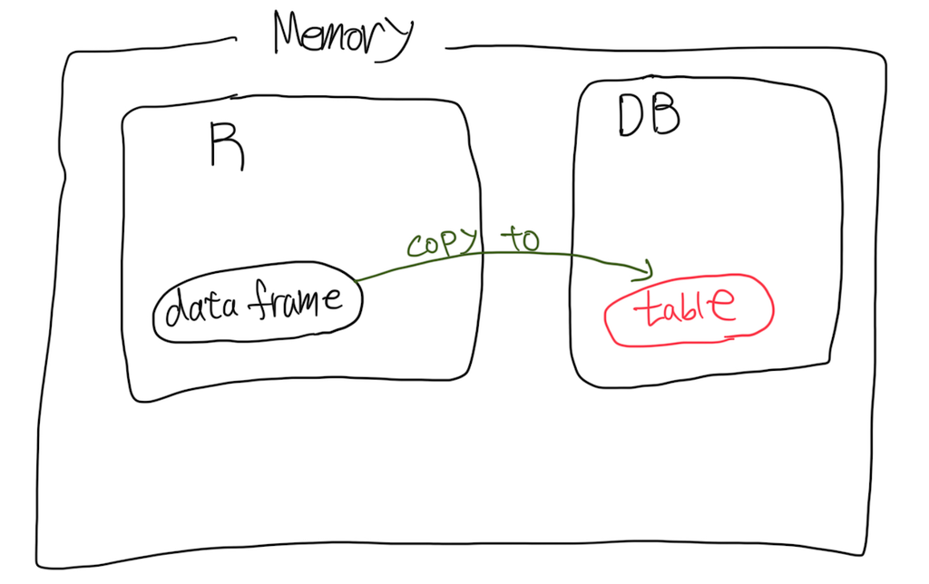

Here I use `duckdb` engine with `dbplyr`.

Copy dataframe (in R memory) to database (in memory).

```r
library(connections)
library(dbplyr)
# establish database connection (in-memory)
con <- connection_open(duckdb::duckdb())

# Copying data to database connection
copy_to(con, stock_prices, name = "stock_price_table")
copy_to(con, sp500_index, name = "sp500_index_table")
```

## Example 1

Running SQL query on the database

```r
tbl(con,
  sql("SELECT symbol, date, adjusted
    FROM stock_price_table
    WHERE symbol = 'AAPL'
    LIMIT 5"))
```

```
# Source:   SQL [?? x 3]
# Database: DuckDB v1.1.3 [root@Darwin 24.3.0:R 4.4.1/:memory:]
  symbol date       adjusted
  <chr>  <date>        <dbl>
1 AAPL   2023-01-03     124.
2 AAPL   2023-01-04     125.
3 AAPL   2023-01-05     124.
4 AAPL   2023-01-06     128.
5 AAPL   2023-01-09     129.
```

To use `dbplyr`, we need to assign R symbol to the database table.

```r
# Assign an R object name to use dbplyr
stock_price_db <- tbl(con, "stock_price_table")
sp500_index_db <- tbl(con, "sp500_index_table")
```

Now dplyr syntax works on the database:

```r
stock_price_db |>
  filter(symbol == "AAPL") |>
  select(symbol, date, adjusted) |>
  head(5)
```

You can see how translation is working with `show_query()`

```r
stock_price_db |>
  filter(symbol == "AAPL") |>
  select(symbol, date, adjusted) |>
  head(5) |>
  show_query()
```

## Exercise

1. Write an SQL query that selects symbol, date, adjusted, and volume from the stock_prices table where volume is less than 50,000,000 and adjusted is greater than 45.
2. Translate the SQL query into dplyr code using `filter()` and `select()`
3. Construct an SQL query that groups the stock_prices table by symbol and calculates the maximum and minimum values of adjusted (naming them max_price and min_price) as well as the count of trading days (as num_days).
4. Rewrite above query into dplyr, and confirm the results.

## Example 2

Complex query example:

```r
tbl(con, sql("
WITH high_weight_symbols AS (
  SELECT symbol
  FROM sp500_index_table
  WHERE weight > 0.03
)
SELECT
  symbol,
  AVG(adjusted) AS avg_price,
  SUM(volume) AS total_volume
FROM stock_price_table
WHERE symbol IN (SELECT symbol FROM high_weight_symbols)
GROUP BY symbol
HAVING AVG(adjusted) > 50
"))
```

```
# Source:   SQL [?? x 3]
# Database: DuckDB v1.1.3 [root@Darwin 24.3.0:R 4.4.1/:memory:]
  symbol avg_price total_volume
  <chr>      <dbl>        <dbl>
1 AAPL        171.  14804257200
2 MSFT        310.   6918889900
```

With `dbplyr`:

```r
subqury <- sp500_index_db |>
      filter(weight > 0.03) |>
      pull(symbol)

stock_price_db |>
  filter(symbol %in% subqury) |>
  group_by(symbol) |>
  summarize(
    avg_price = mean(adjusted),
    total_volume = sum(volume)
  ) |>
  filter(avg_price > 50)
```

```
# Source:   SQL [?? x 3]
# Database: DuckDB v1.1.3 [root@Darwin 24.3.0:R 4.4.1/:memory:]
  symbol avg_price total_volume
  <chr>      <dbl>        <dbl>
1 MSFT        310.   6918889900
2 AAPL        171.  14804257200
```

## Exercise (Challenge)

1. Write an SQL query that
   - A subquery named as active_stocks to extract symbols from sp500_index where weight is above 0.025.
   - Query stock_prices to calculate the average adjusted price (as avg_price) and total volume (as total_volume) and number of days (as trading_days) for these symbols,
   - grouping by symbol and show only those symbols with at least 30 trading days (`HAVING trading_days >= 30`)
2. Convert into dplyr.

## Database Simulation 2

### Creating a local (disk) database

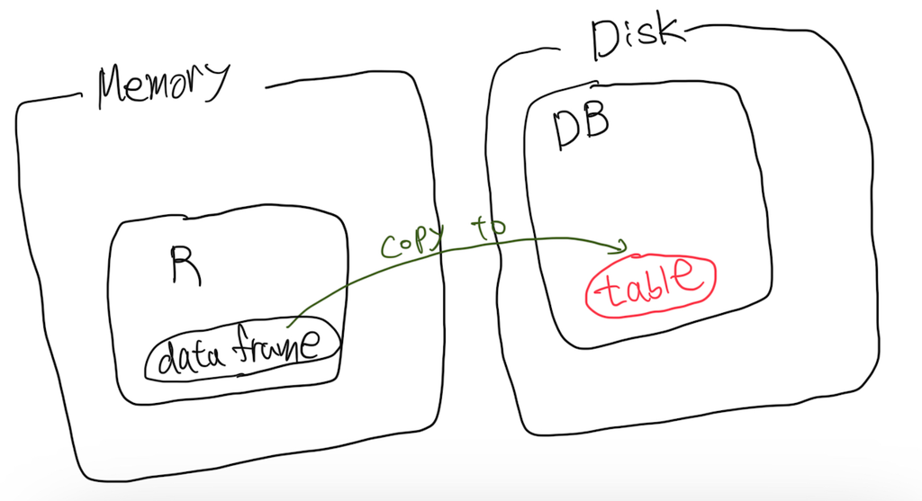

Create on-disk database, with explicit directory address:

```r
# Establish a disk-based connection
con_disk <- connection_open(duckdb::duckdb(), dbdir = "disk_db.duckdb")

# Copying data to database connection
copy_to(con_disk, stock_prices, name = "stock_price_table_disk", temporary = FALSE)
copy_to(con_disk, sp500_index, name = "sp500_index_table_disk", temporary = FALSE)
```

```r
# Assign an R object name to use dbplyr
stock_price_db_disk <- tbl(con_disk, "stock_price_table")
sp500_index_db_disk <- tbl(con_disk, "sp500_index_table")
```

The remaining workflow will be the same as shown in in-memory database.

## Caveats: On-Disk Databases

On-Disk database can handle datasets larger than the system’s memory capacity.

However, overall performance still depends on the system’s memory and disk performance.

- **Processing Considerations:**
  - **Memory Usage:** Complex operations (e.g., joins, sorts) may still be memory intensive.
  - **Disk I/O:** Query performance can be influenced by disk speed.

## Caveats: dbplyr and SQL

Complex `dplyr` syntax may not be fully translate-able to SQL and vice versa. If you use database often, it is worthwhile to learn.

See “The dynamic duo: SQL & R”

- https://posit.co/resources/videos/the-dynamic-duo-sql-and-r/